# Eleições de 2006 e 2010: Uma análise da regressão

Júlio Guedes

2018-09-26

### Importando os pacotes

```r
library(readr)
library(tidyverse)
library(reshape2)
```

### Importando os dados

Nesse lab, estaremos trabalhando com três conjuntos de dados: O conjunto das eleições de 2006, 2010, e um conjunto unindo ambas as eleições. Parte das análises serão feitas considerando os conjuntos separados, enquanto outras considerarão o conjunto unido. Nestes links você pode encontrar o conjunto de dados de [2006](https://canvas.instructure.com/courses/1402758/files/69433650/download?verifier=GvsTSXgoNVf12qbJerOSPAkHsOsdBUZD1Z1AD4lI), [2010](https://canvas.instructure.com/courses/1402758/files/69433651/download?verifier=ZETCucixF5Mkjhfp7CLuchjRXWlSwtw69ZhQ0jyk) e [2006 e 2010](https://canvas.instructure.com/courses/1402758/files/69406530/download?verifier=w88G2kvz56ZJbCSGXgm22zKizUdptatpCDigS9ei&wrap=1)

### Analisando as variáveis

Inicialmente, analisaremos as variáveis importadas no conjunto das eleições de 2006, tentando identificar se há distribuição normal nessas variáveis, e caso não haja, aplicaremos a função log para aproximar da distribuição desejada. Outro objetivo é identificar fatores, fazendo em seguida as transformações necessárias.

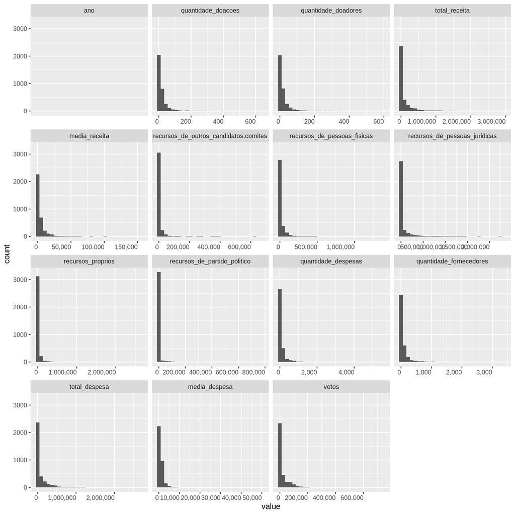

```r
d = melt(eleicoes_2006)
ggplot(d, aes(x = value)) + facet_wrap(~variable, scales="free_x") + geom_histogram() + scale_x_continuous(labels = scales::comma)  + theme(axis.text.x = element_text(hjust = 1))
```

Logo de cara, observamos que a variável “ano” não apresenta valor relevante para a regressão já que, para todos os candidatos, ela possui o valor “2006”.

### Questão 1

Um modelo de regressão múltipla com todas as variáveis é plausível para explicar a variação em y (número de votos) em 2006? Mesma pergunta para 2010.

### Questão 2

Um modelo de regressão múltipla com todas as variáveis é plausível para explicar a variação em y (número de votos) em 2006? Mesma pergunta para 2010.

### Questão 3

Todas as variáveis são úteis para os modelos de regressão? Há variáveis redudantes? Faça análises para 2006 e 2010 separadamente.

### Questão 4

No caso de haver variáveis pouco explicativas e/ou redudantes, construa um novo modelo sem essas variáveis e o compare ao modelo com todas as variáveis (e.g. em termos de R2 e RSE). Faça isso para 2006 e 2010 separadamente.

### Questão 5

Construa agora uma regressão considerando os anos 2006 e 2010 em conjunto. Que diferenças/semelhanças você percebe em relação aos modelos individuais por ano? Veja a questão 2 para sugestões que você usar para comparação.